# PM566lab4

Author

Yuhan Meng

```r
if (!file.exists("met_all.gz"))
  download.file(
    url = "https://raw.githubusercontent.com/USCbiostats/data-science-data/master/02_met/met_all.gz",
    destfile = "met_all.gz",
    method   = "libcurl",
    timeout  = 60
    )
met <- data.table::fread("met_all.gz")
```

```r
library(dplyr)
library(lubridate)
library(tidyverse)
met2<-met[temp>-17][elev==9999.0, elev:=NA]
met[, week:=week(as.Date(paste(year, month, day, sep = "-")))]
met<-met[week==min(week, na.rm = TRUE)]
library(data.table)
met_avg<-met[
  ,
  .(
    temp=mean(temp, na.rm=TRUE),
    rh = mean(rh, na.rm=TRUE),
    wind.sp = mean(wind.sp, na.rm=TRUE),
    vis.dist = mean(vis.dist, na.rm=TRUE),
    dew.point = mean(dew.point, na.rm=TRUE),
    lat = mean(lat, na.rm=TRUE),
    lon = mean(lon, na.rm=TRUE),
    elev = mean(elev, na.rm=TRUE)
  ),
  by = USAFID
  ]
```

```r
met_avg$region <- ifelse(met_avg$lon > -98 & met_avg$lat > 39.71, "northeast",
                  ifelse(met_avg$lon > -98 & met_avg$lat <= 39.71, "southeast",
                  ifelse(met_avg$lon <= -98 & met_avg$lat > 39.71, "northwest",
                         "southwest")))
met_avg$elev_cat<-ifelse(met_avg$elev>252,"high","low")
table(met_avg$region)
```

```
northeast northwest southeast southwest
      486       147       655       300
```

```r
table(met_avg$elev_cat)
```

```
high  low
 767  821
```

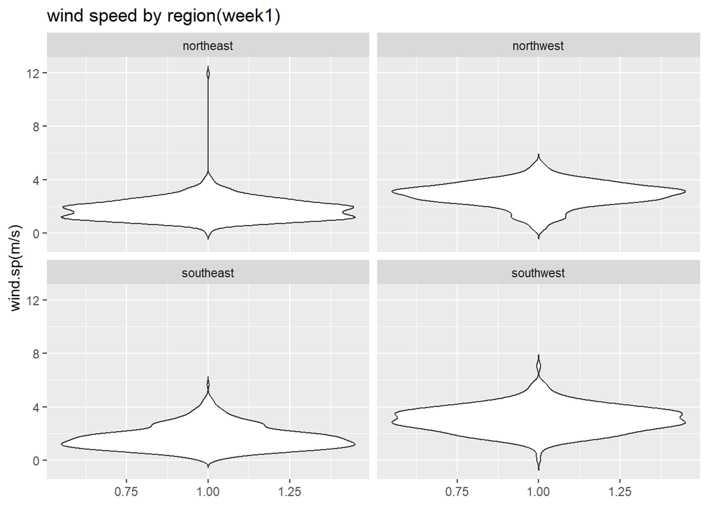

```r
library(ggplot2)
met_avg %>%
  filter(!is.na(wind.sp),!is.na(region))%>%
  ggplot(aes(x = 1,y = wind.sp))+geom_violin(trim=FALSE)+facet_wrap(~ region,nrow = 2)+labs(x=NULL,y="wind.sp(m/s)", title="wind speed by region(week1)")
```

Description of the graph: we can see that the northeast region shows the largest range of wind speed and has few extreme wind speed at about 12m/s. The northwest and southwest regions have moderate wind speeds, mostly between 2 and 6m/s, while the southeast region shows the lowest wind speeds, rarely exceeding 4m/s.

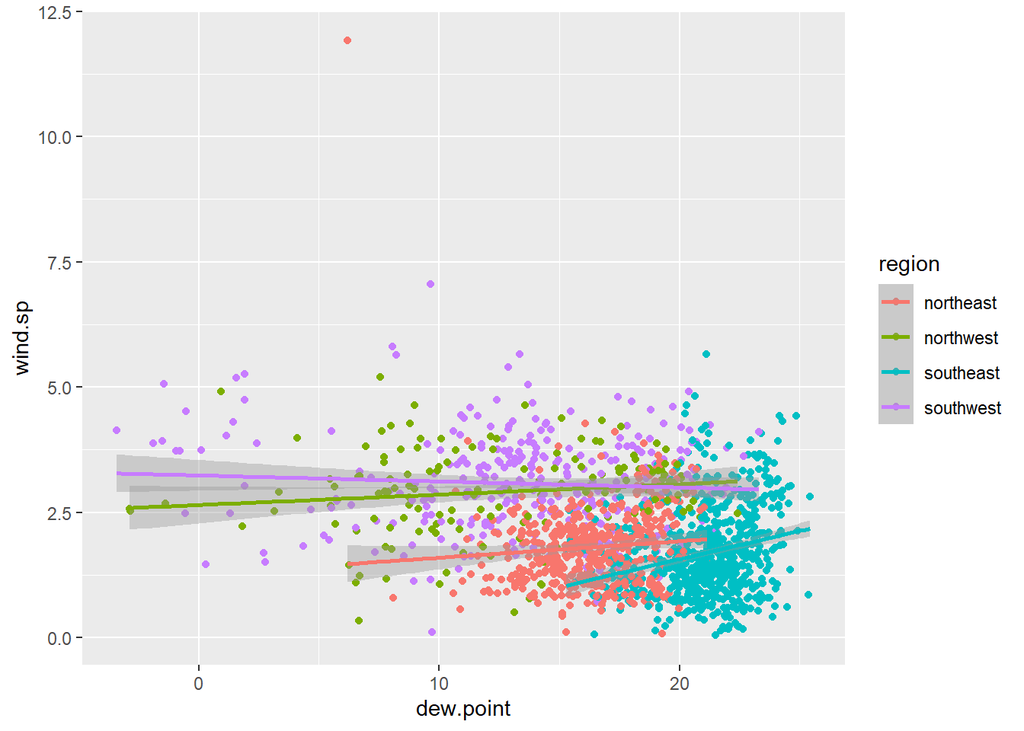

```r
met_avg %>%
  filter(!is.na(dew.point), !is.na(wind.sp)) %>%
  ggplot(aes(x = dew.point, y = wind.sp, color = region)) +
  geom_jitter() +
  stat_smooth(method = "lm")
```

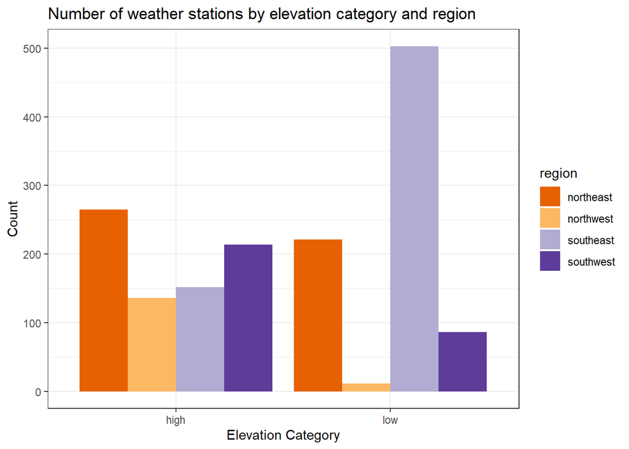

```r
met_avg%>%
  filter(!is.na(elev_cat),!is.na(region)) %>%
  ggplot()+
  geom_bar(aes(x = elev_cat, fill = region),position="dodge")+
  scale_fill_brewer(palette = "PuOr")+
  labs(title="Number of weather stations by elevation category and region",
       x="Elevation Category",y="Count")+
  theme_bw()
```

Description of the graph: we can see that most weather stations are located in the southeast at low elevation, while the northeast has the highest number of stations in the high elevation category. The other regions have relatively fewer stations across both categories.

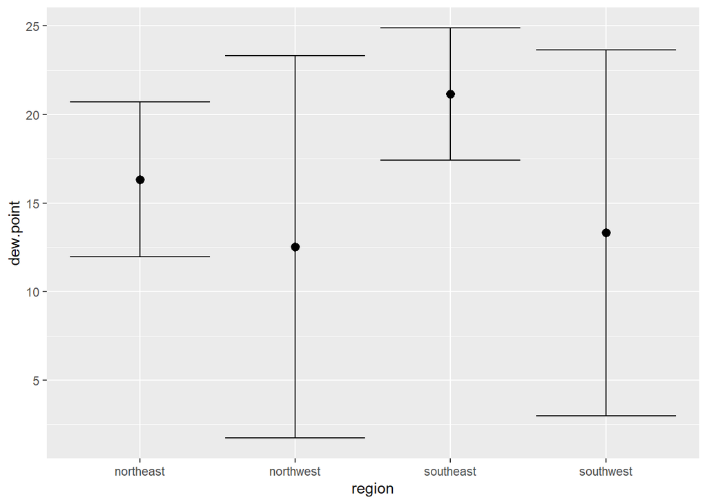

```r
library(dplyr)
library(ggplot2)
met_avg%>%
  filter(!is.na(dew.point),!is.na(wind.sp)) %>%
  ggplot(aes(x = region, y = dew.point ))+
  stat_summary(fun.data = "mean_sdl",geom = "errorbar")+
  stat_summary(fun.data = "mean_sdl")
```

```r
library(dplyr)
library(leaflet)
met_avg2<-met_avg[!is.na(met_avg$rh)]
  top10<-met_avg2[rank(met_avg2$rh)<=10]
rh_pal=colorNumeric(c('blue','purple','red'),domain = met_avg2$rh)
leaflet(met_avg2)%>%
  addProviderTiles("OpenStreetMap")%>%
  addCircles(
    lat = ~lat,lng = ~lon,
    color = ~rh_pal(rh),fillColor = ~rh_pal(rh),
    opacity = 1,fillOpacity = 0.8,radius = 500
    ,label = ~paste0(round(rh,2),"% RH")
  )%>%
  addMarkers(
    data = top10,
    lat = ~lat, lng = ~lon,
    label = ~paste0("Top RH: ", round(rh, 2), "%")
  ) %>%
   addLegend(
    position = "bottomleft",
    pal = rh_pal, values = ~rh,
    title = "Relative Humidity (%)",
    opacity = 1
  )
```

[interactive chart not shown]

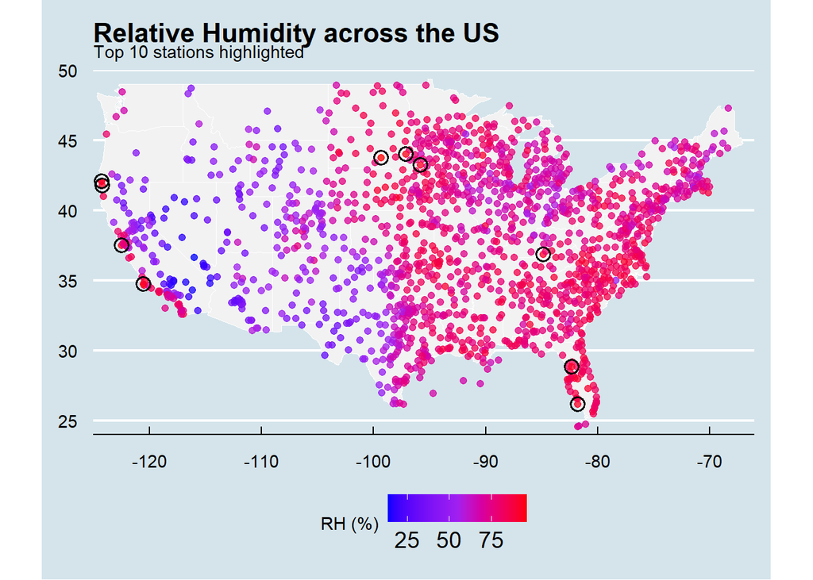

```r
library(dplyr)
library(ggplot2)
library(ggthemes)
library(maps)
map_df <- met_avg %>%
  filter(!is.na(rh), !is.na(lat), !is.na(lon))
top10  <- map_df %>% slice_max(rh, n = 10, with_ties = FALSE)
us <- map_data("state")
ggplot() +
  geom_polygon(data = us, aes(long, lat, group = group),
               fill = "grey95", color = "white", linewidth = 0.2) +
  geom_point(data = map_df,
             aes(x = lon, y = lat, color = rh), alpha = 0.75, size = 1.8) +
  geom_point(data = top10,
             aes(x = lon, y = lat),
             shape = 21, size = 3.6, stroke = 1, fill = NA, color = "black") +
  scale_color_gradientn(colours = c("blue","purple","red"), name = "RH (%)") +  # 连续配色
  coord_quickmap(xlim = c(-125, -66), ylim = c(24, 50), expand = FALSE) +
  labs(title = "Relative Humidity across the US",
       subtitle = "Top 10 stations highlighted",
       x = NULL, y = NULL) +
  theme_economist() +
  theme(legend.position = "bottom",
        panel.grid.minor = element_blank())
```